# Données Ouvertes - Base de données sur les inégalités dans le monde

**Introduction**

Nous avons décidé de nous intéresser au jeu de données des inégalités dans le monde, disponible sur le site https://wid.world/fr/, mis en place suite aux travaux entrepris par Simon Kuznets en 1953, puis poursuivi par A. B. Atkinson et Alan Harrison 1978, étendus sur plusieurs années et de nombreux pays. Le tout a reçu un regain d’intérêt il y a 15 ans, lorsque les inégalités de revenus et de patrimoines sont revenus au premier plan de nos préoccupations. Avec une série d’études, qui a permis d’établir des séries historiques décrivant l’évolution de ces inégalités. Des noms comme ceux de Thomas Piketty, Emmanuel Saez, et Facundo Alvaredo sont désignés comme contributeurs importants de la mise en place et de l’accessibilité de cette base.

Cette base de données est composée de nombreux indicateurs de revenus et de patrimoine des populations par pays, il y est également question d’une division de la population par percentiles. Dans un premier temps, nous allons faire en sorte d’appréhender le jeu de données, en regardant les valeurs de certains indicateurs pour plusieurs pays, ensuite, à l’aide d’une A.C.P., nous allons tenter une méthode non supervisée de classification des pays. Ensuite, nous allons regarder s’il existe des corrélations entre les échanges Erasmus des étudiants en Europe, et les pays où les inégalités sont les plus grandes. On va ensuite représenter les inégalités par des cartes de chaleurs sur le monde avec le package *maps*, et pour finir, Oxfam fournit un rapport sur les inégalités en France, il serait donc intéressant de les recouper.

# 1 Motivations

Pour introduire ce projet, et pour justifier de notre intérêt pour ce sujet, nous avons été inspirés par les travaux de **Lucas Chancel**, dans son rapport sur les inégalités mondiales en 2018. Disponible au lien suivant : http://ses.ens-lyon.fr/fichiers/Articles/diaporama-chancel-cycle-uo-2018-2019.pdf. Fruit d’un travail de recherche tutorée. Le premier graphique de son rapport que nous avons voulu réutiliser donne la part des revenus des 10% les plus aisés dans le monde par découpage régional :

Part des revenus des 10% les plus aisés dans chaque région du monde

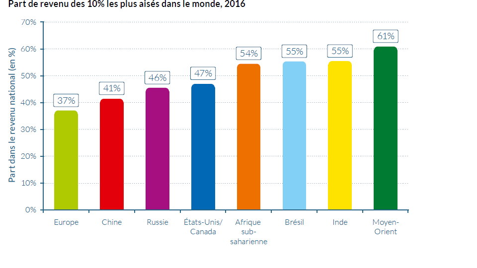

L’inégalité des revenus varie beaucoup d’une région du monde à l’autre. C’est en Europe qu’elle est la plus faible et au Moyen-Orient qu’elle est la plus forte. Les inégalités sont très différentes d’une région à l’autre. En 2016, la part du revenu national allant aux 10 % des plus gros revenus était de 37 % en Europe, 41 % en Chine, 46 % en Russie, 47 % aux États-Unis/Canada, et autour de 55 % en Afrique subsaharienne, au Brésil et en Inde. Au Moyen-Orient, région du monde la plus inégalitaire d’après nos estimations, le décile supérieur captait 61 % du revenu national.

Évolution temporelles du creusement des écarts

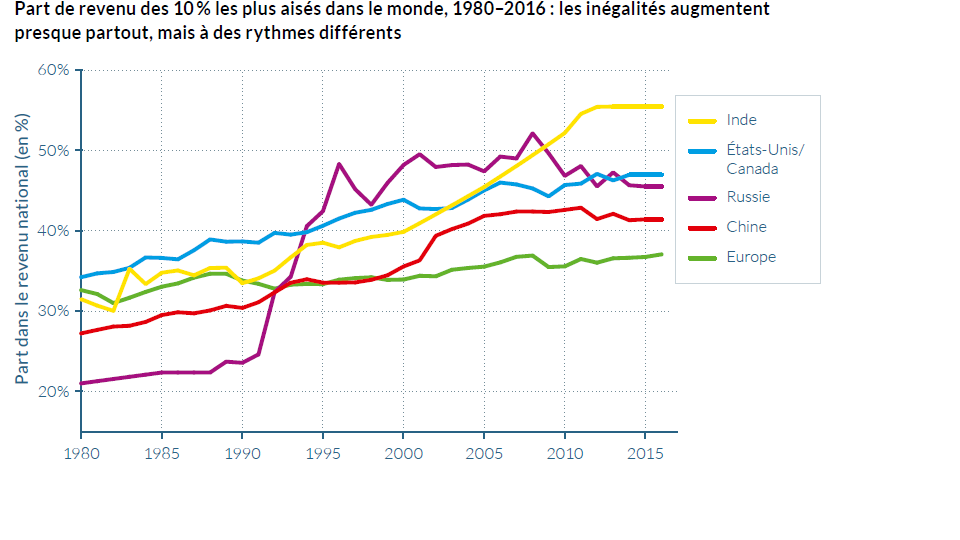

Depuis 1980, les inégalités de revenus ont augmenté rapidement en Amérique du Nord, en Chine, en Inde et en Russie, mais de manière plus modérée en Europe. Dans une perspective historique plus longue, cet accroissement des inégalités marque la fin du régime égalitariste qui avait pris différentes formes dans ces régions après la Seconde Guerre mondiale.

Évolution temporelles du creusement des écarts avec un autre découpage

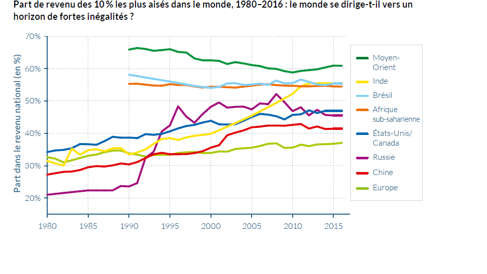

Cette tendance générale connaît des exceptions. Au Moyen-Orient, en Afrique subsaharienne et au Brésil, les inégalités de revenus sont restées relativement stables, à des niveaux très élevés. Les tendances observées dans les différents pays depuis 1980 montrent que les variations en matière d’inégalité sont liées aux contextes institutionnels et politiques variés.

Évolution temporelles du creusement des écarts aux USA

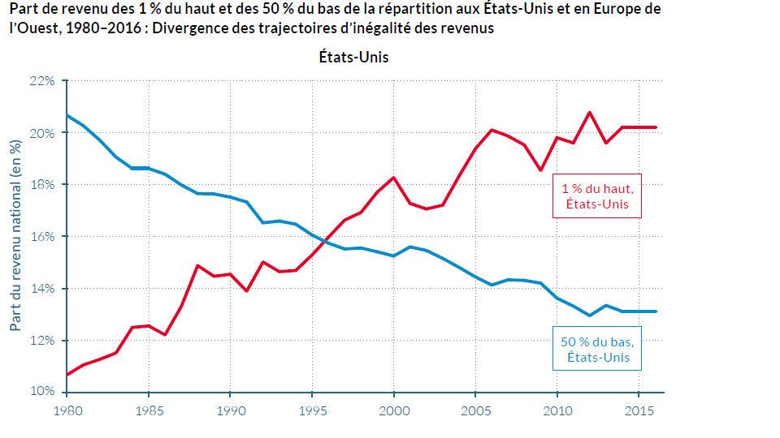

Évolution temporelles du creusement des écarts en Europe

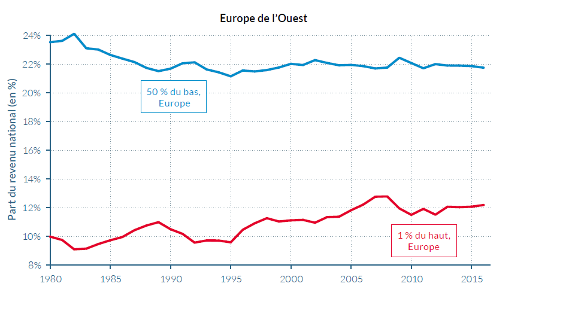

En comparant les États-Unis et l’Europe qui avaient des niveaux d’inégalité comparables en 1980, la divergence est particulièrement extrême. Alors que la part de revenu du centile supérieur était proche de 10 % dans les deux régions en 1980, elle est un peu montée en Europe en 2016 (12 %), mais elle s’est envolée à 20 % aux États-Unis. Dans le même temps, aux États-Unis, la part des 50 % les plus pauvres est passée de plus de 20 % en 1980 à 13 % en 2016. La trajectoire suivie par les États-Unis s’explique en grande partie par une inégalité considérable en matière d’éducation, associée à une fiscalité de moins en moins progressive. En Europe la progressivité de l’impôt baissait, mais dans de moindres proportions ; les inégalités salariales y étaient également freinées par des politiques éducatives et salariales relativement plus favorables aux classes moyennes et populaires. Dans les deux régions, les inégalités de revenus entre hommes et femmes ont reculé, mais elles restent particulièrement marquées au sommet de la distribution. Maintenant essayons de voir comment les inégalités entre les habitants de la planète ont-elles évolué ces dernières décennies ?

Courbe de l’éléphant

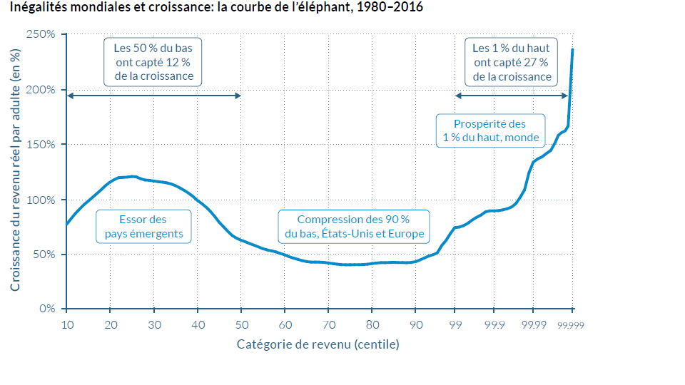

La moitié la plus pauvre de la population mondiale a vu son revenu augmenter de manière significative grâce à la forte croissance de l’Asie (en particulier de la Chine et de l’Inde). Néanmoins, du fait des inégalités prononcées et grandissantes au niveau national depuis 1980, les 1 % d’individus les plus riches dans le monde ont capté deux fois plus de croissance que les 50 % les plus pauvres. Pour les individus situés entre ces deux catégories la croissance du revenu a été faible.

Augmentation de l’écart

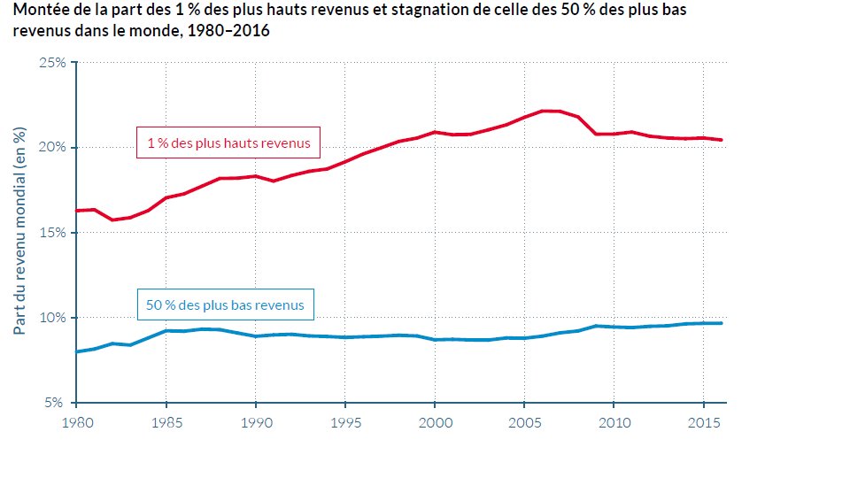

La croissance des inégalités mondiales n’a pas été régulière. Si la part de revenu du centile supérieur est montée de 16 % en 1980 à 22 % en 2000, elle a ensuite légèrement régressé jusqu’à 20 %. La part de revenu allant aux 50 % des individus les plus pauvres dans le monde fluctue autour de 9 % depuis 1980). La rupture de tendance observée après l’an 2000 est liée à une diminution des inégalités de revenus moyens entre pays, puisque les inégalités à l’intérieur des pays ont continué à progresser.

# 2 Le jeu de données

## 2.1 Télechargement via le site web

Notre jeu de données est accessible au téléchargement immédiat via un portail sur le site https://wid.world/fr/donnees, en sélectionnant en amont l’ensemble des données d’intérêt à sélectionner par clic bouton, parmi une liste de pays et/ou une liste de variables comme le revenu, ou encore le patrimoine par centiles. L’ensemble du jeu de données est alors rendu archivé, découpé en fichier pays regroupant dans chaque fichier l’ensemble des variables considérées, évalué par année et, par centile.

Capture d’écran de l’interface de récupération des données

[figure not shown]

## 2.2 Utilisation avec la fonction download_wid()

### 2.2.1 La fonction

Une autre manière d’accéder au jeu de données, c’est par l’intermédiaire d’un package disponible sur le github de **Thomas Blanchet** à l’adresse suivante https://github.com/WIDworld/wid-r-tool, et qui permet de télécharger les données en les sélectionnant de la façon suivante.

```r
download_wid(
    indicators, # Codes correspondants aux variables, aux indicateurs
    areas, # Lieux, pays pour lesquels ont sélectionne les indicateurs demandés au-dessus
    years, # Année prise en compte
    perc, # Percentiles
    ages, # Age groups (adultes, tout les ages, aînés, etc.)
    pop, # Type de population type (individu, foyer, foyer fiscal, etc.)
    metadata, # Variable logique Oui|Non pour le demande d'intégration de métadata (ex: sources, etc.)
    verbose # Variable logique Oui|Non pour l'affichage de la progression du télechargement
)
```

### 2.2.2 Les arguments

L’argument `indicators` est un code alphabétique de 6 caractères qui correspond à un type référencé d’indicateur, prenant en argument chacun des caractères pour définir l’indicateur choisi, on le comprend comme suit : la première lettre qui correspond au type de l’indicateur, par exemple :

Signification de la première lettre

| *a* | average \| la moyenne |
| --- | --- |
| *s* | share \| la part |
| *t* | threshold \| le seuil |
| *m* | macroeconomic total \| total macroéconomique |
| *w* | wealth/income ratio \| ratio de revenu/patrimoine |

Ensuite les 5 lettres suivantes correspondent à la valeur étudiée, en voici quelques exemples:

Signification des 5 lettres suivantes

| *ptinc* | pre-tax national income \| revenu national avant impôt |
| --- | --- |
| *pllin* | pre-tax labor income \| revenu du travail avant impôt |
| *pkkin* | pre-tax capital income \| revenu du capital avant impôt |
| *fiinc* | fiscal income \| revenu fiscal |
| *hweal* | net personal wealth \| patrimoine personnel net |

Pour obtenir de l’aide sur ce code, il suffit de taper la commande `?wid_concepts` qui nous donne la liste totale de ces codes par défaut, l’indicateur est fixé à `"all"` et télécharge l’ensemble des indicateurs disponibles.

Pour les autres paramètres, il semble important de décrire un peu leurs utilisations. Le paramètre `area` correspond aux pays sélectionnables, il fonctionne sur le principe d’un codage ISO de deux lettres, par exemple : *FR=FRANCE, IT=ITALIE*.En plus de pays les `areas` permettent un découpage en région du monde, par exemple : pour avoir le détail des codes ISO des pays, sur le même principe que pour les codages des indicateurs, on peut compiler le code suivant : *QB=AFRICA, US-AL= ALABAMA|USA*. Une liste est accessible en aide avec le code `?wid_area_codes`

En plus des zones et des indicateurs, il nous est possible de sélectionner une partie de la population par année (`years`), percentiles (`perc`) et âge (`âges`). Par défaut l’ensemble de ces paramètres est calibré à `"all"`, qui donne toutes les ressources disponibles. Mais on peut choisir une année ou une période sur laquelle évaluer nos indicateurs (ex : *2000: 2015 prendront les valeurs entre 2000 et 2015), on peut également choisir un découpage de percentile de la population, sélection à l’aide d’un code alpha-numérique défini par le pourcentage de départ et d’arrivée comme **p***début*p*fin* (ex: *p99p100* récupère le top 1% de la population). Pour plus de détails une aide et disponible ici http:/wid.World/percentiles. Passons enfin à l’âge qui permet une segmentation de la population par rapport à leur âge, la sélection se fait grâce à un code de 3 chiffres référencé dans `?wid_age_codes` un petit exemple est donné ici :

Signification des 3 lettres pour “ages”

| *999* | Tout âge |
| --- | --- |
| *992* | Adultes \| + de 20 ans |
| *996* | Adultes sans la tranche 20-60 ans |

Le prochain point sur lequel on peut effectuer une sélection c’est les types de populations étudiées, en effet au sein d’un foyer fiscal, il peut y avoir plusieurs individus, ou encore plus individus fiscaux peuvent être considérés dans une famille. Il est donc important de pouvoir séparé les données en fonction de ces informations. Le code utilisé ici est une lettre, toujours accessible avec l’exécution du code `?wid_population_codes`, en voici quelques exemples :

Signification de la lettre pour “pop”

| *i* | Individu |
| --- | --- |
| *t* | Unité fiscale \| personne ou foyer |
| *j* | Division équitable du foyer entre le nombre d’adultes dans le foyer (ex : couple marié /2) |

Pour finir, la base de données est également composée de metadata sur la provenance des données et les détails méthodologiques des indicateurs obtenus, il suffit si l’on veut télécharger ces informations attribuées la valeur `TRUE` à cet argument. Par défaut, il est réglé sur `FALSE`. Et enfin l’argument `verbose` expliqué dans le cadre $R$ ci-dessus, qui nous donne des informations sur l’avancement du téléchargement.

# 3 Statistiques Déscriptives

## 3.1 Quelques exemples d’utilisation du jeu de données.

Pour se familiariser avec le jeu de données, on se propose de tracer quelques indicateurs sur plusieurs pays, pour comprendre également la fonction *download_wid()*. On se propose de faire un premier test sur le jeu de données pour tracer l’évolution des parts de richesses personnelles du top 10% et du top 1% de 1800 à 2016, en France.

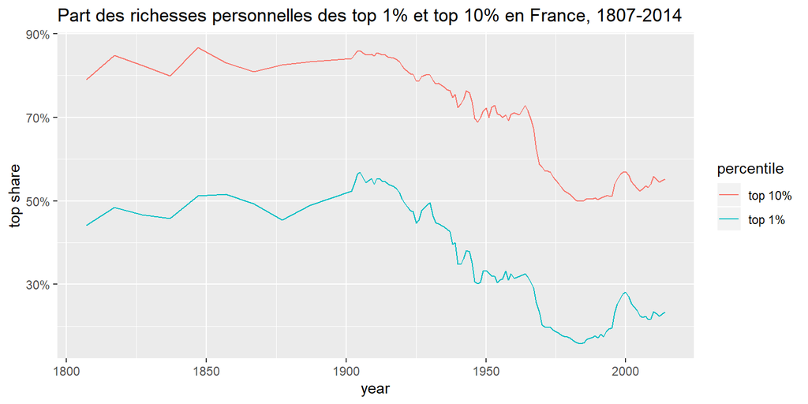

Ici bien que nous n’avons pas précisé les années sur lesquels nous effectuons notre sélection, et que le jeu de données court de l’année à 1800 à 2016, on devrait voir apparaître toutes ces valeurs, cependant notre courbe démarre de 1807, pour aller jusqu’en 2014, il y a donc certaines années qui n’ont pas les données nécessaires.

On se sert encore de nos données, et l’on se propose de tracer un diagramme pour comparer en 2016, les revenus nationaux avant impôts de certains pays européens.

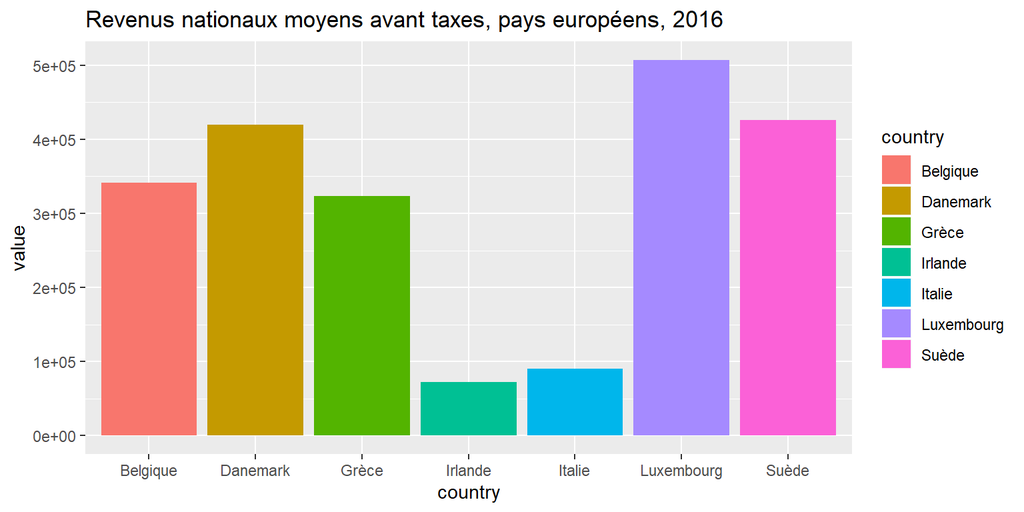

On se rend alors compte qu’uniquement, La Belgique, le Danemark, la Grèce, l’Irlande, l’Italie, le Luxembourg, la Suède apparaissent sur le diagramme, alors que nous avons sélectionné plus de pays, la raison en est la suivante, tous les autres ne sont pas téléchargés car le jeu de données ne contient pas l’indicateur pour ces pays, pour cette année. Imaginons maintenant une tendance sur plusieurs années des revenus nationaux nets moyens, en prenant les adultes avec le code sur `âges`.

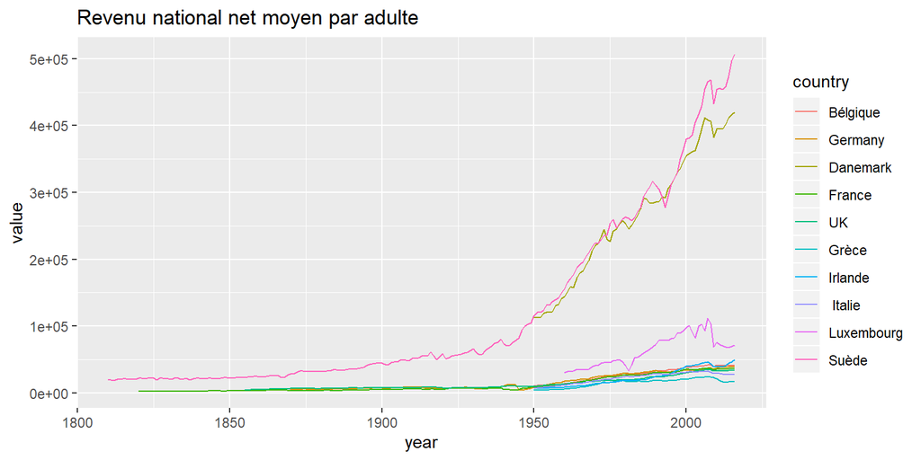

Ici, on se rend compte que le jeu de données peut être compliqué à étudier car il peut rapidement être illisible. De plus il faut faire attention aux devises utilisées dans certains indicateurs, en effet les montants sont donnés en monnaies locales, il faut donc se servir d’un convertisseur de monnaie qui est stocké dans la base de données, on le récupère de la manière suivante.

```r
ppp <- download_wid(
    indicators = "xlcusp", # On récupère la valeur de référence en dollars
    year = 2016 # Année de référence arbitraire
)
```

Et on peut effectuer des comparaisons au niveau des continents, en utilisant à nouveau l’argument `indicators`.

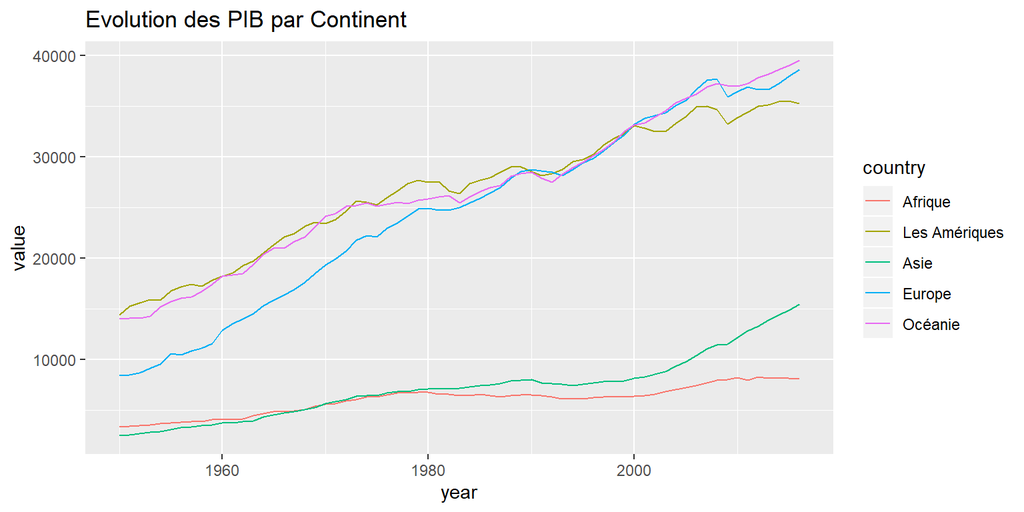

```r
# Average national income data
data <- download_wid(
    indicators = "agdpro", # produit interieur brut moyen
    areas = c("QB", "QC", "QD", "QE", "QF"), # sélection des continents
    ages = 992 # Adultes
)
ggplot(data) +
    geom_line(aes(x=year, y=value, color=country)) +
    scale_color_discrete(
        labels=c("QB"="Afrique", "QC"="Les Amériques", "QD"="Asie", "QE"="Europe", "QF" = "Océanie")
    ) +
    ggtitle("Evolution des PIB par Continent")
```

## 3.2 La représentation des inégalités dans le monde.

Le nom du jeu de données, ainsi que son orientation nous amène à vouloir considérer un indicateur que l’on pourra étudier en profondeur rendant visible les inégalités dans les différents pays. Nous allons donc récupérer les données de la part des richesses des 1% plus riches et des 10%% plus riches sur l’ensemble des pays pour l’ensemble des données, ce qui devrait donc représenter une très grosse base. (Il y a plus de 300 pays, sur plus de 200 ans).

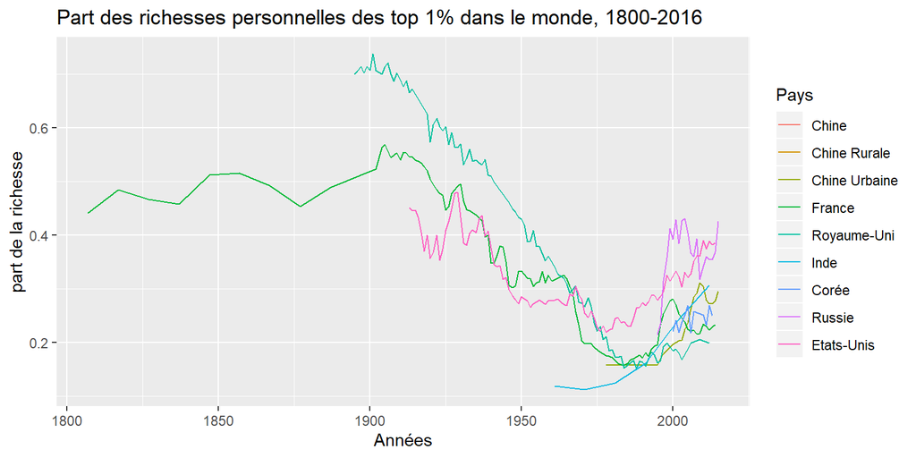

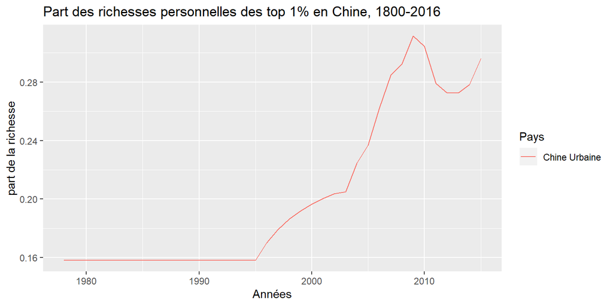

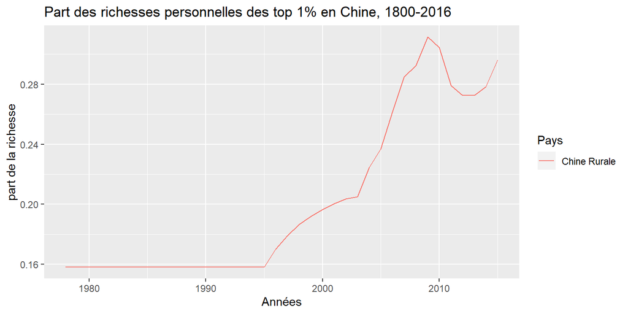

Et l’on se rend compte ici, que le découpage est le même pour le calcul des parts, donc la séparation n’est pas faite pour cet indicateur. Ce manque de cohésion dans le jeu de données, ainsi que les nombres importants de données manquantes rendent les analyses transverses compliquées, on va donc essayer de proposer des méthodes de classification non supervisée, qui pourront nous apporter des analyses plus fines et efficaces.

# 4 Classification non-supervisée.

## 4.1 Dans le monde.

Pour effectuer cette classification non supervisée, au vu du nombre important d’indicateurs, nous allons effectuer une A.C.P, le problème ici, c’est qu’il y a beaucoup de pays et/ou d’années où les données sont manquantes. Dans ces circonstances, il est compliqué d’utiliser une A.C.P, telle que l’on en a l’habitude, nous allons donc nous servir du package de R ’*missMDA*". Dans ce package, les valeurs manquantes ne sont pas simplement remplacées par la moyenne par colonne qui pourrait biaiser les résultats dans le cas de variables corrélées comme l’explique très bien **Monsieur François Husson** dans la vidéo explicative accessible ici : https://www.youtube.com/playlist?list=PLnZgp6epRBbQzxFnQrcxg09kRt-PA66T_

### 4.1.1 Sélection des indicateurs.

Une partie assez longue et fastidieuse a été le choix de nos indicateurs, en effet nombreux sont les indicateurs valables pour aucun pays, en effet certaines combinaisons de code `indicators`, ne retourne aucune valeur. Mais, il existe aussi des indicateurs, dont les valeurs retournées n’existent que pour un seul pays et/ou sur une seule année. Il faut donc tester, et télécharger un à un les indicateurs, ne récupérant uniquement ceux dont il y a assez de matériel pour travailler.

Voici notre sélection :

```r
income <- download_wid(
    indicators = "mnninc", # Revenu national moyen
    perc = "p0p100",
    years = 2015
)
grossproduct <- download_wid(
    indicators = "mgdpro", # produit domestique brut
    perc = "p0p100",
    years = 2015
)
natioconso <- download_wid(
    indicators = "mconfc", # Consomation de l'économie national
    perc = "p0p100",
    years = 2015
)
detpers <- download_wid(
    indicators = "ahwdeb", # dettes personnelles moyennes
    perc = "p0p100",
    years = 2015,
    ages = 999
)
richpers <- download_wid(
    indicators = "ahweal", # richesses  personnelles moyennes
    perc = "p0p100",
    years = 2015,
    ages = 999
)
detgouv <- download_wid(
    indicators = "agwdeb", # dettes gouvernementales
    perc = "p0p100",
    years = 2015,
    ages = 999
)
```

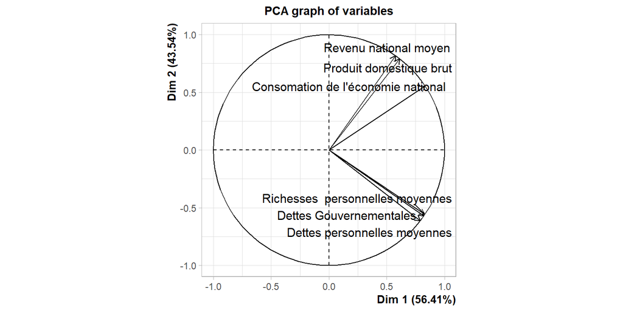

Regardons quelques individus aléatoirement :

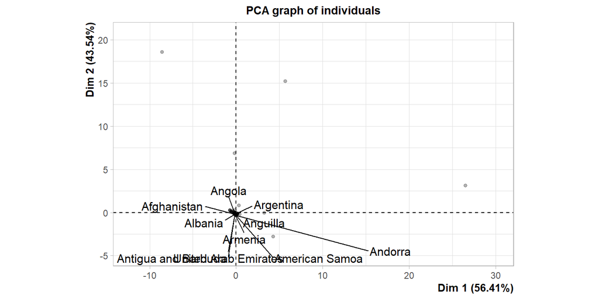

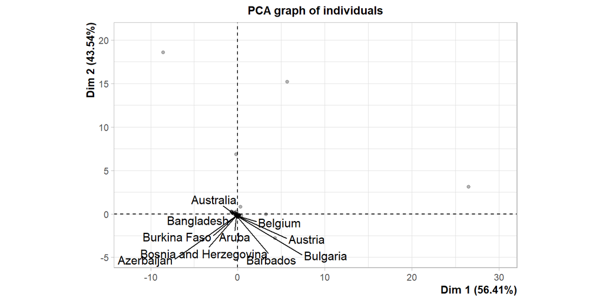

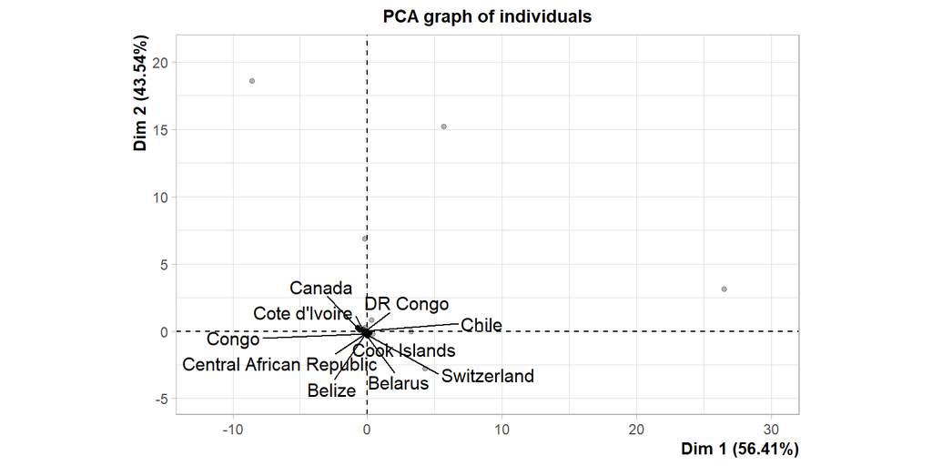

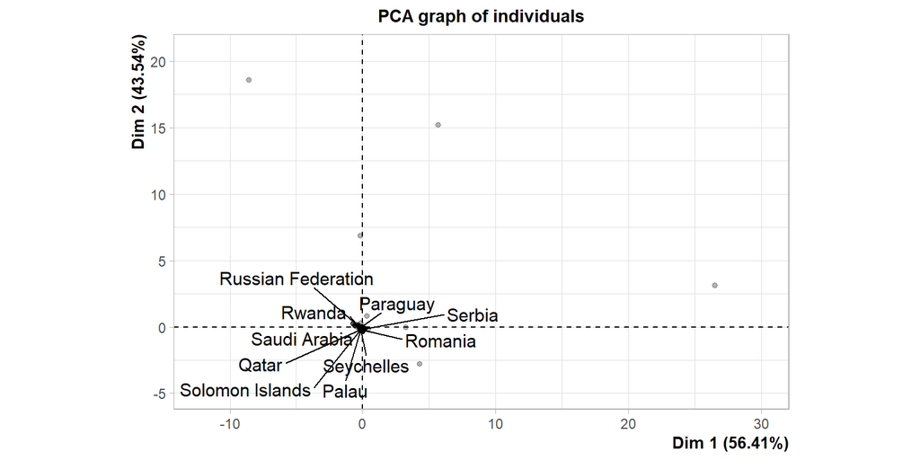

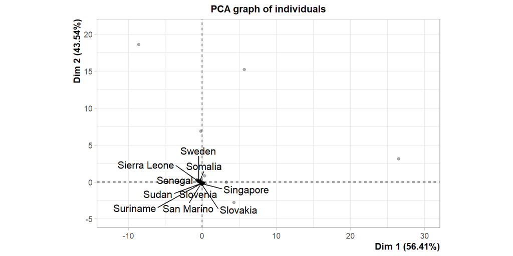

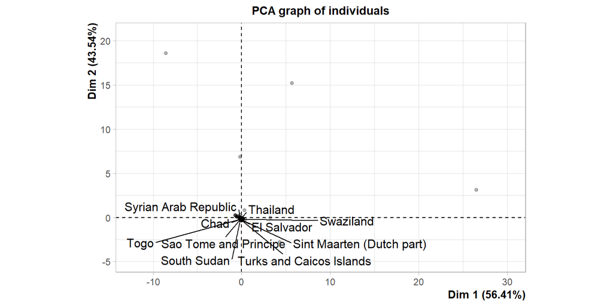

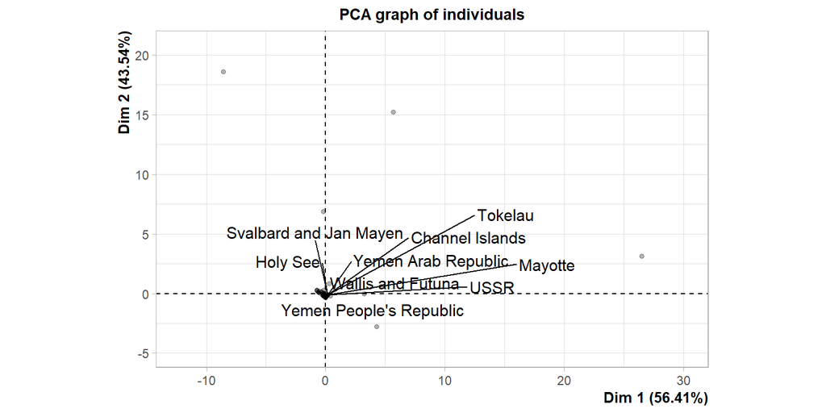

On se rend donc très vite compte qu’il est compliqué d’émettre de bonnes conclusions de classification sur deux axes avec autant de pays, on se propose alors de prendre en compte les pays de l’union européenne, pour se demander, si l’on peut décrire la variabilité du jeu de données dans une ACP.

```r
summary(res.PCA)
```

```
##
## Call:
## PCA(X = pca$completeObs, graph = F)
##
##
## Eigenvalues
##                        Dim.1   Dim.2   Dim.3   Dim.4   Dim.5   Dim.6
## Variance               3.385   2.612   0.002   0.001   0.000   0.000
## % of var.             56.410  43.542   0.033   0.011   0.002   0.001
## Cumulative % of var.  56.410  99.952  99.985  99.997  99.999 100.000
##
## Individuals (the 10 first)
##                                        Dist    Dim.1    ctr   cos2    Dim.2
## Andorra                            |  0.321 | -0.002  0.000  0.000 | -0.321
## United Arab Emirates               |  0.266 | -0.164  0.003  0.377 | -0.210
## Afghanistan                        |  0.267 | -0.166  0.003  0.389 | -0.208
## Antigua and Barbuda                |  0.268 | -0.165  0.003  0.380 | -0.211
## Anguilla                           |  0.321 | -0.002  0.000  0.000 | -0.321
## Albania                            |  0.266 | -0.165  0.003  0.382 | -0.209
## Armenia                            |  0.261 | -0.161  0.003  0.382 | -0.205
## Angola                             |  0.235 | -0.163  0.003  0.480 | -0.169
## Argentina                          |  0.249 | -0.154  0.003  0.381 | -0.196
## American Samoa                     |  0.321 | -0.002  0.000  0.000 | -0.321
##                                       ctr   cos2    Dim.3    ctr   cos2
## Andorra                             0.016  1.000 |  0.000  0.000  0.000 |
## United Arab Emirates                0.007  0.623 |  0.001  0.000  0.000 |
## Afghanistan                         0.007  0.611 |  0.001  0.000  0.000 |
## Antigua and Barbuda                 0.007  0.620 |  0.001  0.000  0.000 |
## Anguilla                            0.016  1.000 |  0.000  0.000  0.000 |
## Albania                             0.007  0.618 |  0.001  0.000  0.000 |
## Armenia                             0.006  0.618 |  0.001  0.000  0.000 |
## Angola                              0.004  0.520 |  0.002  0.000  0.000 |
## Argentina                           0.006  0.619 |  0.001  0.000  0.000 |
## American Samoa                      0.016  1.000 |  0.000  0.000  0.000 |
##
## Variables
##                                       Dim.1    ctr   cos2    Dim.2    ctr
## Revenu national moyen              |  0.576  9.818  0.332 |  0.817 25.539
## Produit domestique brut            |  0.613 11.094  0.375 |  0.790 23.897
## Consomation de l'économie national |  0.831 20.424  0.691 |  0.554 11.766
## Dettes personnelles moyennes       |  0.790 18.429  0.624 | -0.613 14.385
## Richesses  personnelles moyennes   |  0.829 20.312  0.687 | -0.559 11.958
## Dettes Gouvernementales            |  0.821 19.924  0.674 | -0.570 12.454
##                                      cos2    Dim.3    ctr   cos2
## Revenu national moyen               0.667 |  0.021 22.195  0.000 |
## Produit domestique brut             0.624 |  0.013  8.559  0.000 |
## Consomation de l'économie national  0.307 | -0.037 66.555  0.001 |
## Dettes personnelles moyennes        0.376 |  0.005  1.270  0.000 |
## Richesses  personnelles moyennes    0.312 |  0.004  0.860  0.000 |
## Dettes Gouvernementales             0.325 |  0.003  0.562  0.000 |
```

## 4.2 En Europe.

### 4.2.1 Sélection des indicateurs

On se propose de reprendre les mêmes indicateurs. Avec cette fois-ci, la sélection des pays européens avec l’argument `areas`.

```r
income <- download_wid(
    indicators = "mnninc", # Revenu national moyen
    areas = c("AD", "AL", "AM", "AT", "BA", "BE", "BG", "BY", "CH", "CY", "CZ", "DE", "DK", "EE",
              "ES", "FI", "FR", "GB", "GR", "HR", "HU", "IE", "IS", "IT", "LT", "LV", "MK", "MT",
              "NL", "NO", "PL", "PT", "RO", "RS", "SE", "SI", "SK", "UA"),
    perc = "p0p100",
    years = 2015
)
```

### 4.2.2 Réalisation de l’analyse en composantes principales

On représente donc tous les pays petit à petit, pour une meilleure visibilité.

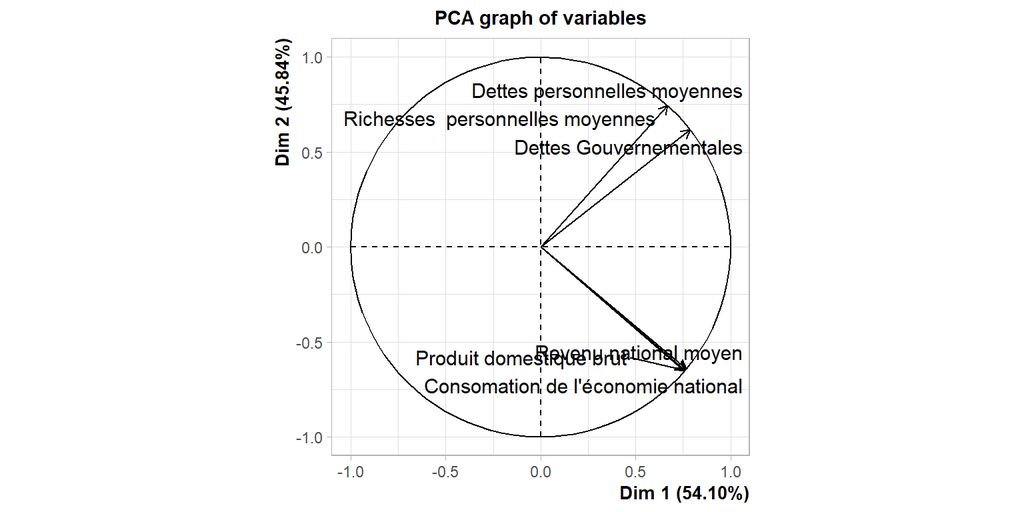

```r
nb <- estim_ncpPCA(data[,c(5,7,9,11,13,15)], scale = T)
pca <- imputePCA(data[,c(5,7,9,11,13,15)], ncp = 2, scale = T)
res.PCA <- PCA(pca$completeObs, graph = F)
plot.PCA(res.PCA, choix = "var", graph.type = "ggplot")
```

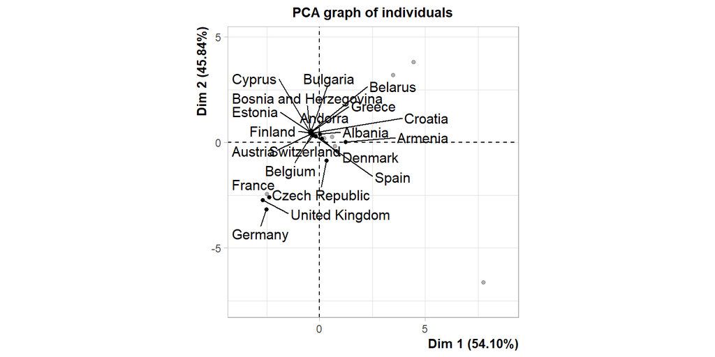

```r
plot.PCA(res.PCA, choix = "ind", graph.type = "ggplot", select = 1:20)
```

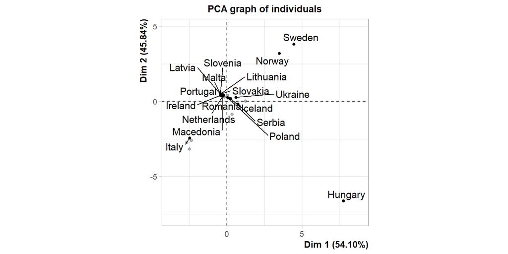

```r
plot.PCA(res.PCA, choix = "ind", graph.type = "ggplot", select = 21:38)
```

```r
summary(res.PCA)
```

```
##
## Call:
## PCA(X = pca$completeObs, graph = F)
##
##
## Eigenvalues
##                        Dim.1   Dim.2   Dim.3   Dim.4   Dim.5   Dim.6
## Variance               3.246   2.750   0.003   0.000   0.000   0.000
## % of var.             54.101  45.840   0.056   0.002   0.000   0.000
## Cumulative % of var.  54.101  99.941  99.998 100.000 100.000 100.000
##
## Individuals (the 10 first)
##                                        Dist    Dim.1    ctr   cos2    Dim.2
## Andorra                            |  0.676 | -0.399  0.129  0.348 |  0.546
## Albania                            |  0.401 |  0.014  0.000  0.001 |  0.398
## Armenia                            |  1.241 |  1.224  1.214  0.972 |  0.031
## Austria                            |  0.563 | -0.370  0.111  0.432 |  0.424
## Bosnia and Herzegovina             |  0.663 | -0.445  0.160  0.450 |  0.491
## Belgium                            |  0.538 | -0.361  0.106  0.450 |  0.398
## Bulgaria                           |  0.644 | -0.429  0.149  0.443 |  0.481
## Belarus                            |  0.639 | -0.422  0.144  0.435 |  0.480
## Switzerland                        |  0.463 | -0.316  0.081  0.466 |  0.336
## Cyprus                             |  0.666 | -0.449  0.163  0.454 |  0.492
##                                       ctr   cos2    Dim.3    ctr   cos2
## Andorra                             0.285  0.652 |  0.000  0.000  0.000 |
## Albania                             0.151  0.981 | -0.053  2.236  0.018 |
## Armenia                             0.001  0.001 | -0.202 31.915  0.026 |
## Austria                             0.172  0.567 |  0.021  0.345  0.001 |
## Bosnia and Herzegovina              0.231  0.549 |  0.019  0.288  0.001 |
## Belgium                             0.151  0.547 |  0.026  0.534  0.002 |
## Bulgaria                            0.221  0.557 |  0.018  0.260  0.001 |
## Belarus                             0.220  0.564 |  0.017  0.223  0.001 |
## Switzerland                         0.108  0.528 |  0.034  0.906  0.005 |
## Cyprus                              0.231  0.545 |  0.020  0.312  0.001 |
##
## Variables
##                                       Dim.1    ctr   cos2    Dim.2    ctr
## Revenu national moyen              |  0.764 18.004  0.584 | -0.644 15.060
## Produit domestique brut            |  0.760 17.773  0.577 | -0.650 15.376
## Consomation de l'économie national |  0.755 17.572  0.570 | -0.654 15.547
## Dettes personnelles moyennes       |  0.669 13.778  0.447 |  0.743 20.097
## Richesses  personnelles moyennes   |  0.669 13.778  0.447 |  0.743 20.097
## Dettes Gouvernementales            |  0.787 19.095  0.620 |  0.617 13.822
##                                      cos2    Dim.3    ctr   cos2
## Revenu national moyen               0.414 | -0.036 39.332  0.001 |
## Produit domestique brut             0.423 | -0.008  1.951  0.000 |
## Consomation de l'économie national  0.428 |  0.044 58.714  0.002 |
## Dettes personnelles moyennes        0.553 |  0.000  0.001  0.000 |
## Richesses  personnelles moyennes    0.553 |  0.000  0.001  0.000 |
## Dettes Gouvernementales             0.380 |  0.000  0.001  0.000 |
```

Une autre méthode de classification non supervisée pour le regroupement de pays serait les k-means avec la sélection du nombre de barycentre, ici il semble que nous en ayant identifié 3. Nous allons donc tenter d’utiliser un algorithme des k-means pour la classification non supervisée.

## 4.3 K-means.

On effectue tout d’abord un petit traitement sur les valeurs manquantes.

```r
fn <- function(x){
           m. <- mean(x, na.rm = TRUE)
           x[is.na(x)] <- m.
           x
}
data <- t(apply(data[,c(5,7,9,11,13,15)], 1, fn))
```

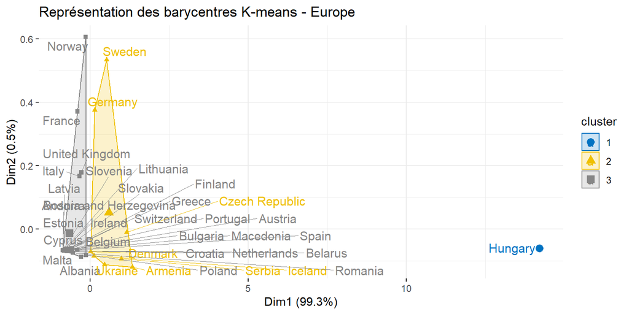

```r
km <- kmeans(scale(data), centers=3, nstart=25)
fviz_cluster(km, data,
             ellipse.type="convex",
             repel = TRUE,            # Evite le chevauchement des textes
             show.clust.cent = TRUE, # Montre le centre des clusters
             palette = "jco",         # Palette de couleurs, voir ?ggpubr::ggpar
             ggtheme = theme_minimal(),
             main = "Représentation des barycentres K-means - Europe")
```

On remarque que la Hongrie est alors très éloignée des autres groupes, il serait intéressant d’effectuer à nouveau ce travail en ne prenant pas en compte la Hongrie dans notre travail.

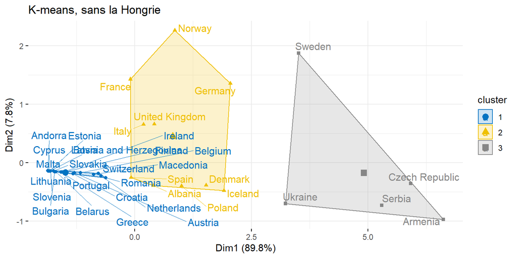

```r
km <- kmeans(scale(data[-21,]), centers=3, nstart=25)
fviz_cluster(km, data[-21,],
             ellipse.type="convex",
             repel = TRUE,            # Evite le chevauchement des textes
             show.clust.cent = TRUE, # Montre le centre des clusters
             palette = "jco",         # Palette de couleurs, voir ?ggpubr::ggpar
             ggtheme = theme_minimal(),
             main = "K-means, sans la Hongrie")
```

On obtient alors un découpage vraiment différent, on doit tout de même faire attention notre méthode pour gérer les valeurs manquantes ici, manque de rigueur comparée à celle utilisée par l’ACP du package *missMDA*. On peut également utiliser les dendrogrammes pour la classification.

## 4.4 Dendrogramme de groupement.

### 4.4.1 Sur les données brutes

Avec la classification hiérarchique. On se décide à éliminer à nouveau la Hongrie, qui influe énormément sur nos résultats. On décide de le représenter de deux manières différentes.

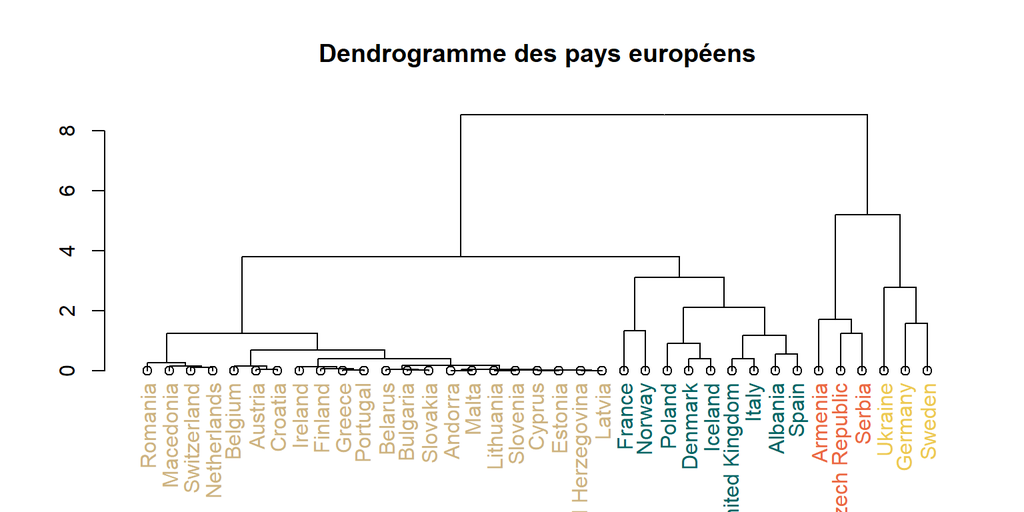

```r
hc <- hclust(dist(scale(data[-21,])))
labelColors = c("#CDB380", "#036564", "#EB6841", "#EDC951")
clusMember = cutree(hc, 4)
colLab <- function(n) {
    if (is.leaf(n)) {
        a <- attributes(n)
        labCol <- labelColors[clusMember[which(names(clusMember) == a$label)]]
        attr(n, "nodePar") <- c(a$nodePar, lab.col = labCol)
    }
    n
}
clusDendro = dendrapply(as.dendrogram(hc), colLab)
plot(clusDendro, main = "Dendrogramme des pays européens")
```

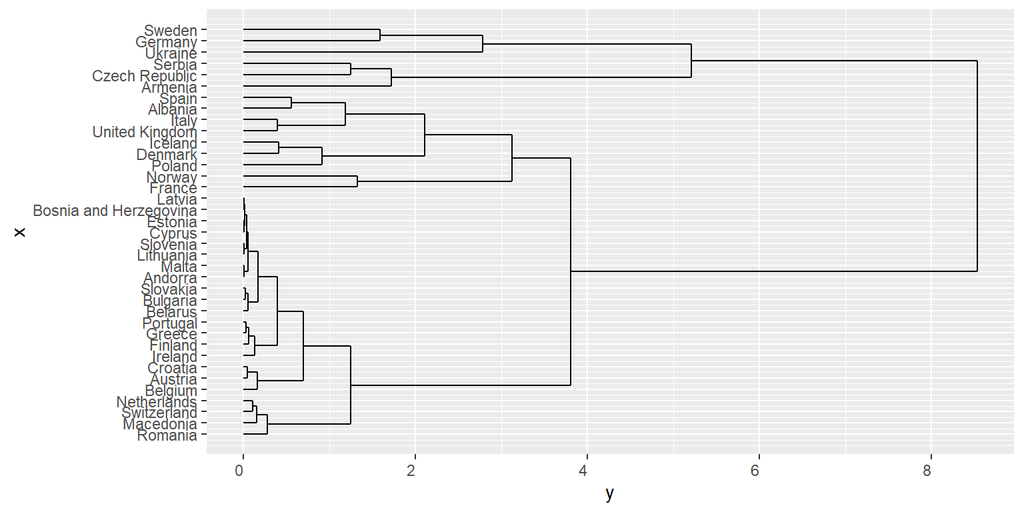

```r
ggdendrogram(hc, rotate = TRUE, size = 4, theme_dendro = FALSE, color=c("#CDB380", "#036564", "#EB6841", "#EDC951"))
```

### 4.4.2 Sur les résultats de l’ACP.

Il est intéressant de se servir également des résultats de l’A.C.P pour la construction de nos outils de classification non supervisée.

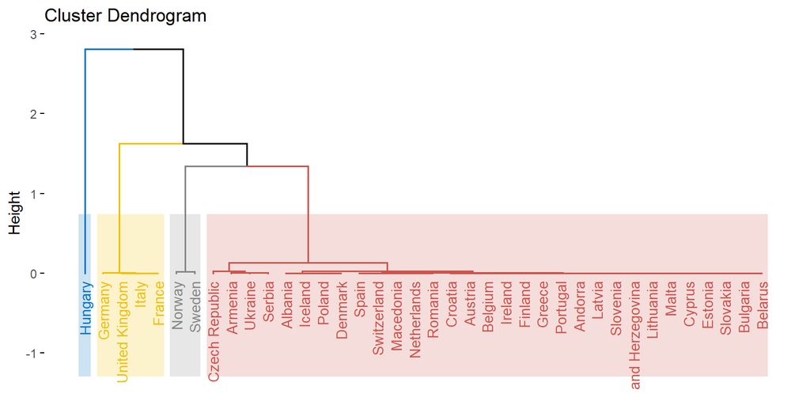

```r
res.hcpc <- HCPC(res.PCA, graph = FALSE)
fviz_dend(res.hcpc,
          cex = 0.7,                     # Taille du text
          palette = "jco",               # Palette de couleur ?ggpubr::ggpar
          rect = TRUE, rect_fill = TRUE, # Rectangle autour des groupes
          rect_border = "jco",           # Couleur du rectangle
          labels_track_height = 0.8      # Augment l'espace pour le texte
          )
```

Là encore, la Hongrie se démarque par son éloignement, mais on arrive un peu à retrouver nos groupes obtenus lors de l’ACP.